# BlackFriday

```python
import numpy as np
import pandas as pd
import matplotlib.pyplot as plt
import seaborn as sns
```

```python
train_df = pd.read_csv("C:/Users/hrish/Downloads/BlackFriday/train.csv")
train_df
test_df = pd.read_csv("C:/Users/hrish/Downloads/BlackFriday/test.csv")
```

```python
train_df.head()
```

|  | User_ID | Product_ID | Gender | Age | Occupation | City_Category | Stay_In_Current_City_Years | Marital_Status | Product_Category_1 | Product_Category_2 | Product_Category_3 | Purchase |
| --- | --- | --- | --- | --- | --- | --- | --- | --- | --- | --- | --- | --- |
| 0 | 1000001 | P00069042 | F | 0-17 | 10 | A | 2 | 0 | 3 | NaN | NaN | 8370 |
| 1 | 1000001 | P00248942 | F | 0-17 | 10 | A | 2 | 0 | 1 | 6.0 | 14.0 | 15200 |
| 2 | 1000001 | P00087842 | F | 0-17 | 10 | A | 2 | 0 | 12 | NaN | NaN | 1422 |
| 3 | 1000001 | P00085442 | F | 0-17 | 10 | A | 2 | 0 | 12 | 14.0 | NaN | 1057 |
| 4 | 1000002 | P00285442 | M | 55+ | 16 | C | 4+ | 0 | 8 | NaN | NaN | 7969 |

```python
test_df.head()
```

|  | User_ID | Product_ID | Gender | Age | Occupation | City_Category | Stay_In_Current_City_Years | Marital_Status | Product_Category_1 | Product_Category_2 | Product_Category_3 |
| --- | --- | --- | --- | --- | --- | --- | --- | --- | --- | --- | --- |
| 0 | 1000004 | P00128942 | M | 46-50 | 7 | B | 2 | 1 | 1 | 11.0 | NaN |
| 1 | 1000009 | P00113442 | M | 26-35 | 17 | C | 0 | 0 | 3 | 5.0 | NaN |
| 2 | 1000010 | P00288442 | F | 36-45 | 1 | B | 4+ | 1 | 5 | 14.0 | NaN |
| 3 | 1000010 | P00145342 | F | 36-45 | 1 | B | 4+ | 1 | 4 | 9.0 | NaN |
| 4 | 1000011 | P00053842 | F | 26-35 | 1 | C | 1 | 0 | 4 | 5.0 | 12.0 |

```python
test_df.info()
```

```
<class 'pandas.core.frame.DataFrame'>
RangeIndex: 233599 entries, 0 to 233598
Data columns (total 11 columns):
 #   Column                      Non-Null Count   Dtype
---  ------                      --------------   -----
 0   User_ID                     233599 non-null  int64
 1   Product_ID                  233599 non-null  object
 2   Gender                      233599 non-null  object
 3   Age                         233599 non-null  object
 4   Occupation                  233599 non-null  int64
 5   City_Category               233599 non-null  object
 6   Stay_In_Current_City_Years  233599 non-null  object
 7   Marital_Status              233599 non-null  int64
 8   Product_Category_1          233599 non-null  int64
 9   Product_Category_2          161255 non-null  float64
 10  Product_Category_3          71037 non-null   float64
dtypes: float64(2), int64(4), object(5)
memory usage: 19.6+ MB
```

```python
train_df.info()
```

```
<class 'pandas.core.frame.DataFrame'>
RangeIndex: 550068 entries, 0 to 550067
Data columns (total 12 columns):
 #   Column                      Non-Null Count   Dtype
---  ------                      --------------   -----
 0   User_ID                     550068 non-null  int64
 1   Product_ID                  550068 non-null  object
 2   Gender                      550068 non-null  object
 3   Age                         550068 non-null  object
 4   Occupation                  550068 non-null  int64
 5   City_Category               550068 non-null  object
 6   Stay_In_Current_City_Years  550068 non-null  object
 7   Marital_Status              550068 non-null  int64
 8   Product_Category_1          550068 non-null  int64
 9   Product_Category_2          376430 non-null  float64
 10  Product_Category_3          166821 non-null  float64
 11  Purchase                    550068 non-null  int64
dtypes: float64(2), int64(5), object(5)
memory usage: 50.4+ MB
```

```python
train_df.describe(include="all")
```

|  | User_ID | Product_ID | Gender | Age | Occupation | City_Category | Stay_In_Current_City_Years | Marital_Status | Product_Category_1 | Product_Category_2 | Product_Category_3 | Purchase |
| --- | --- | --- | --- | --- | --- | --- | --- | --- | --- | --- | --- | --- |
| count | 5.500680e+05 | 550068 | 550068 | 550068 | 550068.000000 | 550068 | 550068 | 550068.000000 | 550068.000000 | 376430.000000 | 166821.000000 | 550068.000000 |
| unique | NaN | 3631 | 2 | 7 | NaN | 3 | 5 | NaN | NaN | NaN | NaN | NaN |
| top | NaN | P00265242 | M | 26-35 | NaN | B | 1 | NaN | NaN | NaN | NaN | NaN |
| freq | NaN | 1880 | 414259 | 219587 | NaN | 231173 | 193821 | NaN | NaN | NaN | NaN | NaN |
| mean | 1.003029e+06 | NaN | NaN | NaN | 8.076707 | NaN | NaN | 0.409653 | 5.404270 | 9.842329 | 12.668243 | 9263.968713 |
| std | 1.727592e+03 | NaN | NaN | NaN | 6.522660 | NaN | NaN | 0.491770 | 3.936211 | 5.086590 | 4.125338 | 5023.065394 |
| min | 1.000001e+06 | NaN | NaN | NaN | 0.000000 | NaN | NaN | 0.000000 | 1.000000 | 2.000000 | 3.000000 | 12.000000 |
| 25% | 1.001516e+06 | NaN | NaN | NaN | 2.000000 | NaN | NaN | 0.000000 | 1.000000 | 5.000000 | 9.000000 | 5823.000000 |
| 50% | 1.003077e+06 | NaN | NaN | NaN | 7.000000 | NaN | NaN | 0.000000 | 5.000000 | 9.000000 | 14.000000 | 8047.000000 |
| 75% | 1.004478e+06 | NaN | NaN | NaN | 14.000000 | NaN | NaN | 1.000000 | 8.000000 | 15.000000 | 16.000000 | 12054.000000 |
| max | 1.006040e+06 | NaN | NaN | NaN | 20.000000 | NaN | NaN | 1.000000 | 20.000000 | 18.000000 | 18.000000 | 23961.000000 |

```python
print("All coluumns ->{}".format(list(train_df.columns)))
print()
print("Total Transactions -> {}".format(train_df.shape[0]))

unique_users = len(train_df.User_ID.unique())
print("Total unique users ->{}".format(unique_users))

unique_products = len(train_df.Product_ID.unique())
print("Total unique products -> {}".format(unique_products))
```

```
All coluumns ->['User_ID', 'Product_ID', 'Gender', 'Age', 'Occupation', 'City_Category', 'Stay_In_Current_City_Years', 'Marital_Status', 'Product_Category_1', 'Product_Category_2', 'Product_Category_3', 'Purchase']

Total Transactions -> 550068
Total unique users ->5891
Total unique products -> 3631
```

```python
(train_df.isnull().sum()*100/train_df.shape[0]).sort_values(ascending = False)
```

```
Product_Category_3            69.672659
Product_Category_2            31.566643
Purchase                       0.000000
Product_Category_1             0.000000
Marital_Status                 0.000000
Stay_In_Current_City_Years     0.000000
City_Category                  0.000000
Occupation                     0.000000
Age                            0.000000
Gender                         0.000000
Product_ID                     0.000000
User_ID                        0.000000
dtype: float64
```

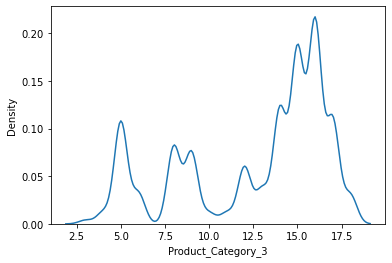

```python
sns.kdeplot(train_df['Product_Category_3'])
plt.show()
```

```python
vc = train_df['Product_Category_3'].value_counts(normalize=True)
null = train_df['Product_Category_3'].isnull()
train_df.loc[null,'Product_Category_3'] = np.random.choice(vc.index,size = null.sum(),p=vc.values)
```

```python
train_df['Product_Category_3'].isnull().sum()
```

```
0
```

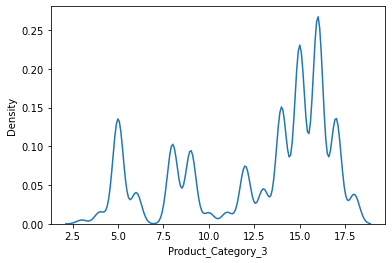

```python
sns.kdeplot(train_df['Product_Category_3'])
plt.show()
```

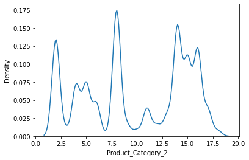

```python
sns.kdeplot(train_df['Product_Category_2'])
plt.show()
```

```python
vc = train_df['Product_Category_2'].value_counts(normalize=True)
null = train_df['Product_Category_2'].isnull()
train_df.loc[null,'Product_Category_2'] = np.random.choice(vc.index, size = null.sum(), p =vc.values)
```

```python
train_df['Product_Category_2'].isnull().sum()
```

```
0
```

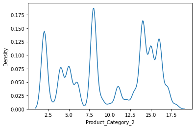

```python
sns.kdeplot(train_df['Product_Category_2'])
plt.show()
```

```python
train_df = train_df.drop('Product_Category_3', axis=1)
test_df = test_df.drop('Product_Category_3', axis=1)
```

##===================================================================== ####Total Purchasing Amount Paid group by Age, Gender, Occupation, City , Years Stay In current City and marital status #####Questions :- 1. Which age group have spent more in black friday? 2. Have females spent more than males ? 3. Do users' occupation have any relation on spending money at black friday? 4. Do users who are living in the city more than 1 year have spent more money? 5. Does category of city have any imapact on total purchase amount? 6. Does marital status is related to the black friday?

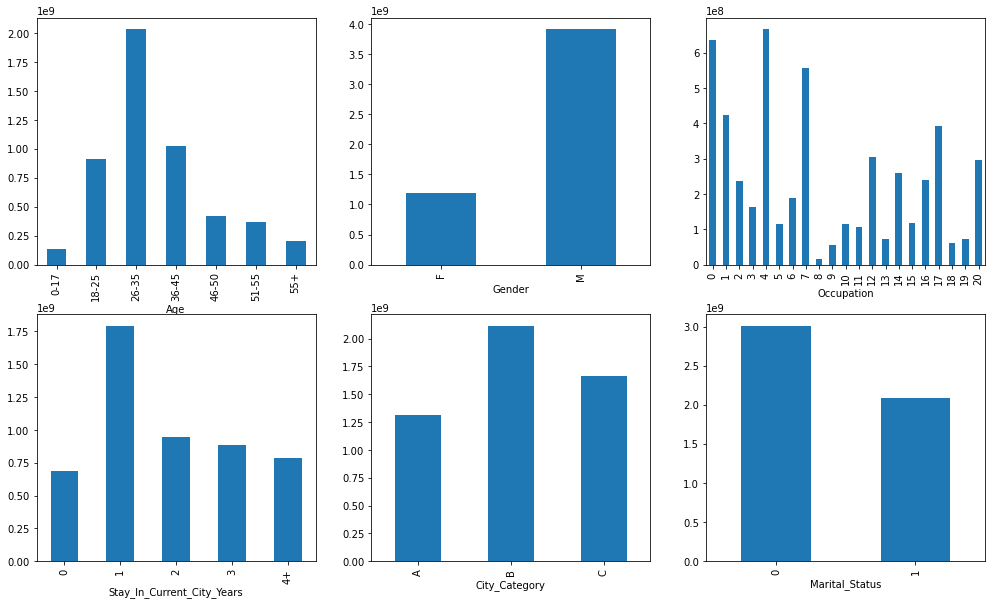

```python
fig,axis = plt.subplots(nrows=2,ncols=3,figsize=(17,10))

train_df.groupby(["Age"])["Purchase"].sum().plot(kind='bar',ax=axis[0,0])
train_df.groupby(["Gender"])["Purchase"].sum().plot(kind='bar',ax=axis[0,1])
train_df.groupby(["Occupation"])["Purchase"].sum().plot(kind='bar',ax=axis[0,2])
train_df.groupby(["City_Category"])["Purchase"].sum().plot(kind='bar',ax=axis[1,1])
train_df.groupby(["Stay_In_Current_City_Years"])["Purchase"].sum().plot(kind='bar',ax=axis[1,0])
train_df.groupby(["Marital_Status"])["Purchase"].sum().plot(kind='bar',ax=axis[1,2])
```

#### From Above Figures we can conclude that, ##### Conclusions :- * In figure 1, 26-35 age range have spent more money. * In figure 2, Male users have spent more money. * In figure 3, Users whose occupations are 0 and 4 have spent more money. * In figure 4, Users who stayed in current city for 1 year have spent more money. * In figure 5, Users from city category B have spent more money. * In figure 6, Users who are not married yet have spent more money.## ===================================================================== #### Let's see the total Purchased Amount by gender by Age, Occupation, Years Stay In current City and marital status

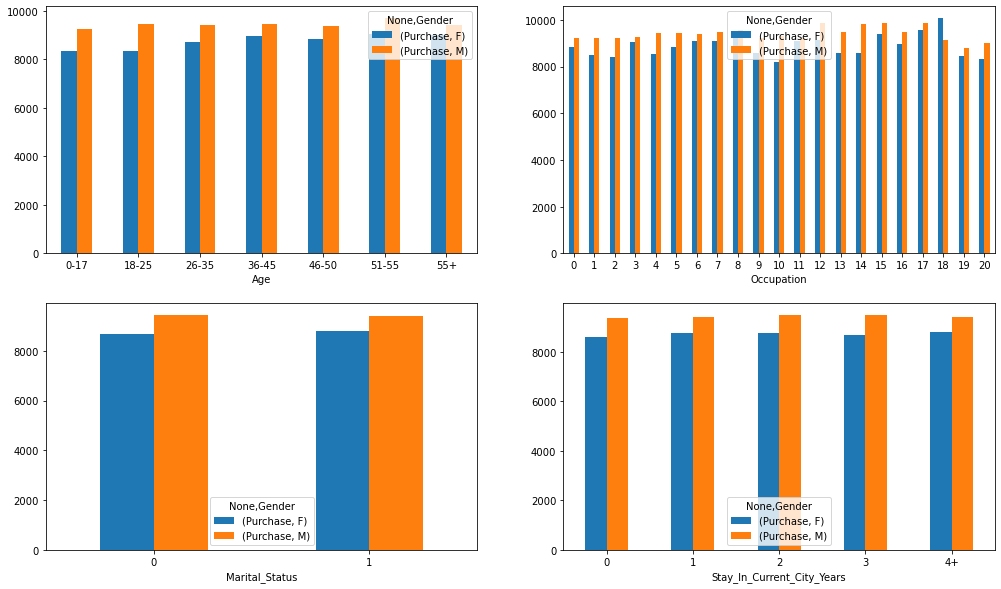

```python
fig,axis = plt.subplots(nrows=2,ncols=2,figsize=(17,10))

train_df.groupby(["Age","Gender"])[["Purchase"]].mean().unstack().plot(kind='bar',rot=0, ax = axis[0,0])
train_df.groupby(["Occupation","Gender"])[["Purchase"]].mean().unstack().plot(kind='bar',rot=0, ax = axis[0,1])
train_df.groupby(["Marital_Status","Gender"])[["Purchase"]].mean().unstack().plot(kind='bar',rot=0, ax = axis[1,0])
train_df.groupby(["Stay_In_Current_City_Years","Gender"])[["Purchase"]].mean().unstack().plot(kind='bar',rot=0, ax = axis[1,1])
```

#### From Above Figures we can conclude that, ##### Conclusions :- * In figure 1, Male users have spent more money across each age group. * In figure 2, Male users have spent more money than the females with an exception for males and females working in occupation 18 * In figure 3, Single and married males have shopped more than the females * In figure 4, Males have spent more than their female counterparts irrespective of their duration of stay in a city

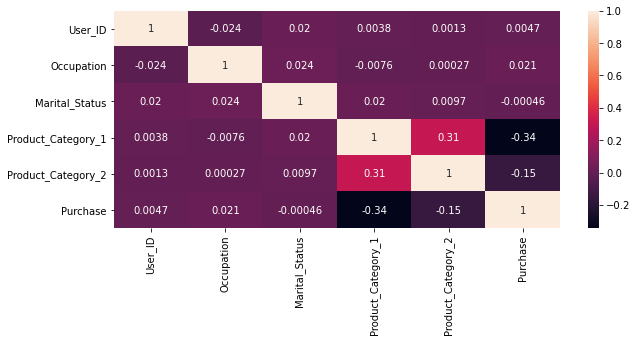

```python
plt.figure(figsize=(10,4))
sns.heatmap(train_df.corr(),annot=True)
plt.show()
```

```python
a = pd.crosstab(train_df['Age'],train_df['User_ID'])
a
```

| User_ID Age | 1000001 | 1000002 | 1000003 | 1000004 | 1000005 | 1000006 | 1000007 | 1000008 | 1000009 | 1000010 | ... | 1006031 | 1006032 | 1006033 | 1006034 | 1006035 | 1006036 | 1006037 | 1006038 | 1006039 | 1006040 |
| --- | --- | --- | --- | --- | --- | --- | --- | --- | --- | --- | --- | --- | --- | --- | --- | --- | --- | --- | --- | --- | --- |
| 0-17 | 35 | 0 | 0 | 0 | 0 | 0 | 0 | 0 | 0 | 0 | ... | 0 | 0 | 0 | 0 | 0 | 0 | 0 | 0 | 0 | 0 |
| 18-25 | 0 | 0 | 0 | 0 | 0 | 0 | 0 | 0 | 0 | 0 | ... | 31 | 0 | 0 | 0 | 0 | 0 | 0 | 0 | 0 | 0 |
| 26-35 | 0 | 0 | 29 | 0 | 106 | 0 | 0 | 77 | 58 | 0 | ... | 0 | 0 | 0 | 12 | 152 | 514 | 0 | 0 | 0 | 180 |
| 36-45 | 0 | 0 | 0 | 0 | 0 | 0 | 17 | 0 | 0 | 223 | ... | 0 | 0 | 0 | 0 | 0 | 0 | 0 | 0 | 0 | 0 |
| 46-50 | 0 | 0 | 0 | 14 | 0 | 0 | 0 | 0 | 0 | 0 | ... | 0 | 55 | 0 | 0 | 0 | 0 | 122 | 0 | 74 | 0 |
| 51-55 | 0 | 0 | 0 | 0 | 0 | 47 | 0 | 0 | 0 | 0 | ... | 0 | 0 | 36 | 0 | 0 | 0 | 0 | 0 | 0 | 0 |
| 55+ | 0 | 77 | 0 | 0 | 0 | 0 | 0 | 0 | 0 | 0 | ... | 0 | 0 | 0 | 0 | 0 | 0 | 0 | 12 | 0 | 0 |

7 rows × 5891 columns

```python
b = pd.DataFrame()
b['Maximum Purchase Count'] = a.max(axis=1)
b['User_ID'] = a.idxmax(axis=1).values
b.index = a.index
b
```

| Age | Maximum Purchase Count | User_ID |
| --- | --- | --- |
| 0-17 | 680 | 1001088 |
| 18-25 | 698 | 1003391 |
| 26-35 | 1026 | 1001680 |
| 36-45 | 979 | 1004277 |
| 46-50 | 823 | 1000889 |
| 51-55 | 502 | 1003292 |
| 55+ | 767 | 1003618 |

This table shows us which User has made the most number of purchases in a particular age group

```python
#Set Stay_In_Current_City_Years = 4+ as 4.
train_df['Stay_In_Current_City_Years'] = train_df['Stay_In_Current_City_Years'].replace('4+','4')
train_df['Stay_In_Current_City_Years'] = train_df['Stay_In_Current_City_Years'].astype('int64')

test_df['Stay_In_Current_City_Years'] = test_df['Stay_In_Current_City_Years'].replace('4+','4')
test_df['Stay_In_Current_City_Years'] = test_df['Stay_In_Current_City_Years'].astype('int64')
```

```python
from sklearn.preprocessing import LabelEncoder
le = LabelEncoder()
train_df['LE_Age'] = le.fit_transform(train_df.Age)
```

```python
test_df['LE_Age'] = le.fit_transform(test_df.Age)
```

```python
compare = pd.DataFrame(columns=['Label','Age'])
compare['Label']=train_df['LE_Age'].value_counts().index
compare['Age']=train_df['Age'].value_counts().index
compare.sort_values(by='Label')
```

|  | Label | Age |
| --- | --- | --- |
| 6 | 0 | 0-17 |
| 2 | 1 | 18-25 |
| 0 | 2 | 26-35 |
| 1 | 3 | 36-45 |
| 3 | 4 | 46-50 |
| 4 | 5 | 51-55 |
| 5 | 6 | 55+ |

```python
compareT = pd.DataFrame(columns=['Label','Age'])
compareT['Label']=test_df['LE_Age'].value_counts().index
compareT['Age']=test_df['Age'].value_counts().index
compareT.sort_values(by='Label')
```

|  | Label | Age |
| --- | --- | --- |
| 6 | 0 | 0-17 |
| 2 | 1 | 18-25 |
| 0 | 2 | 26-35 |
| 1 | 3 | 36-45 |
| 3 | 4 | 46-50 |
| 4 | 5 | 51-55 |
| 5 | 6 | 55+ |

```python
test_df = test_df.drop('Age',axis=1)
```

```python
train_df = train_df.drop('Age',axis=1)
```

```python
# Removing the the prefix 'P' from Product ID and converting it to an integer
train_df['Product_ID']=train_df['Product_ID'].str.lstrip('P').astype('int64')
```

```python
test_df['Product_ID']=test_df['Product_ID'].str.lstrip('P').astype('int64')
```

```python
train_df=pd.get_dummies(train_df,drop_first=True)
train_df.head()
```

|  | User_ID | Product_ID | Occupation | Stay_In_Current_City_Years | Marital_Status | Product_Category_1 | Product_Category_2 | Purchase | LE_Age | Gender_M | City_Category_B | City_Category_C |
| --- | --- | --- | --- | --- | --- | --- | --- | --- | --- | --- | --- | --- |
| 0 | 1000001 | 69042 | 10 | 2 | 0 | 3 | 8.0 | 8370 | 0 | 0 | 0 | 0 |
| 1 | 1000001 | 248942 | 10 | 2 | 0 | 1 | 6.0 | 15200 | 0 | 0 | 0 | 0 |
| 2 | 1000001 | 87842 | 10 | 2 | 0 | 12 | 6.0 | 1422 | 0 | 0 | 0 | 0 |
| 3 | 1000001 | 85442 | 10 | 2 | 0 | 12 | 14.0 | 1057 | 0 | 0 | 0 | 0 |
| 4 | 1000002 | 285442 | 16 | 4 | 0 | 8 | 2.0 | 7969 | 6 | 1 | 0 | 1 |

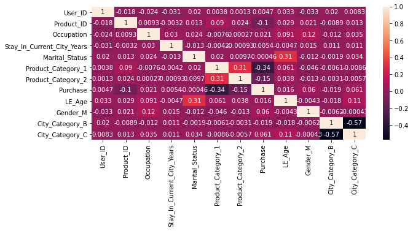

```python
plt.figure(figsize=(10,4))
sns.heatmap(train_df.corr(),annot=True)
plt.show()
```

```python
test_df=pd.get_dummies(test_df,drop_first=True)
test_df.head()
```

|  | User_ID | Product_ID | Occupation | Stay_In_Current_City_Years | Marital_Status | Product_Category_1 | Product_Category_2 | LE_Age | Gender_M | City_Category_B | City_Category_C |
| --- | --- | --- | --- | --- | --- | --- | --- | --- | --- | --- | --- |
| 0 | 1000004 | 128942 | 7 | 2 | 1 | 1 | 11.0 | 4 | 1 | 1 | 0 |
| 1 | 1000009 | 113442 | 17 | 0 | 0 | 3 | 5.0 | 2 | 1 | 0 | 1 |
| 2 | 1000010 | 288442 | 1 | 4 | 1 | 5 | 14.0 | 3 | 0 | 1 | 0 |
| 3 | 1000010 | 145342 | 1 | 4 | 1 | 4 | 9.0 | 3 | 0 | 1 | 0 |
| 4 | 1000011 | 53842 | 1 | 1 | 0 | 4 | 5.0 | 2 | 0 | 0 | 1 |

```python
X = train_df.drop('Purchase', axis=1)
y = train_df['Purchase']
```

```python
from sklearn.model_selection import train_test_split
X_train, X_test, y_train, y_test = train_test_split(X,y,test_size=0.2,random_state=0)

from sklearn.preprocessing import StandardScaler
ss=StandardScaler()
X_train_std=pd.DataFrame(ss.fit_transform(X_train),columns=X_train.columns)
X_test_std=pd.DataFrame(ss.transform(X_test),columns=X_test.columns)
```

linear regression

```python
from sklearn.linear_model import LinearRegression
from sklearn.metrics import r2_score, mean_squared_error

lr=LinearRegression()
lr.fit(X_train_std,y_train)
y_pred_test=lr.predict(X_test_std)


print('R^2 on the test data', r2_score(y_test, y_pred_test))
print('RMSE on the test data', np.sqrt(mean_squared_error(y_test, y_pred_test)))
```

```
R^2 on the test data 0.13286313982028308
RMSE on the test data 4679.42152417866
```

Decision tree

```python
from sklearn.tree import DecisionTreeRegressor
dt = DecisionTreeRegressor(max_depth=10, min_samples_leaf=500)
dt.fit(X_train, y_train)
y_pred_test=dt.predict(X_test)

print('R^2 on the test data', r2_score(y_test, y_pred_test))
print('RMSE on the test data', np.sqrt(mean_squared_error(y_test, y_pred_test)))
```

```
R^2 on the test data 0.6796500768649674
RMSE on the test data 2844.203435397655
```

Random Forest

```python
from sklearn.ensemble import RandomForestRegressor

rf = RandomForestRegressor(n_estimators=30,random_state=3,max_depth=15,min_samples_split=100)
rf.fit(X_train,y_train)
y_pred_test=rf.predict(X_test)

print('R^2 on the test data', r2_score(y_test, y_pred_test))
print('RMSE on the test data', np.sqrt(mean_squared_error(y_test, y_pred_test)))
```

```
R^2 on the test data 0.7130681720494576
RMSE on the test data 2691.7685035999248
```

Xg Boost

```python
from xgboost import XGBRegressor
from sklearn.preprocessing import StandardScaler

xgb= XGBRegressor(learning_rate=0.05,n_estimators=500,max_depth=10)
xgb.fit(X_train,y_train)

y_pred_test=xgb.predict(X_test)
print('R^2 on the test data', r2_score(y_test, y_pred_test))
print('RMSE on the test data', np.sqrt(mean_squared_error(y_test, y_pred_test)))
```

```
R^2 on the test data 0.749367302746182
RMSE on the test data 2515.7484196691385
```